# Yu-Gi-Oh! Meets Data Analysis!

Gabriel SH (yeye), tutored by Geeked.id

9/9/2021

# 1. Introduction

## 1.1 A Bit About Me

Hellow, I’m Gabriel, but you may call me Yeye for convenience, and I would prefer you to call me that :)

## 1.2 A bit about Yu-Gi-Oh!

In this portofolio builder, I would like to to analyze **Yu-Gi-Oh!** card game, spesifically the TCG (English) version. YGO is in my kind of *biased* opinion, the best card game I’ve ever played, and I stumbled upon this dataset by chance.

Sadly though, I have left playing it since long ago because of **money** issues. If you don’t know, a single card can cost a maximum of **Rp 1.000.000**, or maybe more.

And also, for simplicity, I’ll refer to **Yu-Gi-Oh!** simply as **YGO**.

## 1.3 A Little Note About This Portofolio

In this portofolio, I want to explore `tidyverse`, which is R package (more like a bundle), that can `generalize` the style of data analysis using R, since many people have different coding styles / approach, using `tidyverse` makes the code style uniform and much more simple and easy to understand.

## 1.4 Libraries

```r
library(dplyr)
library(lemon)
library(data.table)
library(ggplot2)
```

# 2. Meet The Data

## 2.1 Dataset Brief

The datasets are provided by [James Palmer](https://www.kaggle.com/jpalmer2) from `kaggle.com`, and the data itself was scraped from [Yu-Gi-Oh! Fandom Wiki](https://yugioh.fandom.com/wiki/Yu-Gi-Oh!). It consist of 4 files, which upon slight inspection, it’s actually quite similar.

```r
yugi <- read.csv("dataset/yugi.csv")
View(yugi)
```

## 2.2 Dataset Characteristics

### 2.2.1 Parameters

- **Name** : Card name
- **Card.Type** : Monster / Spell / Trap card
- **Attribute** : Monster Attribute (LIGHT, DARK, EARTH, WATER, etc)
- **Monster.Type** : Monster type (Fairy, Zombie, Fiend, Pyro, etc), also represents the Monster Type (Synchro, Effect, Xyz, etc)
- **Level.Rank** : Monster Level / Xyz Monster Rank
- **ATK.DEF** : ATK & DEF of the monster
- **Passcode** : Card code printed on the bottom left side
- **Materials…Ritual.spell** : Material for Synchro Monsters / Fusion Monsters / Xyz Monsters / Link Monsters
- **Effect.Type** : This is a bit complex, but I can give you an easy example, suppose it’s *Continuous* , then as long as that card is face up on the field, the effect will remain.
- **Effect** : The actual effect of the card printed on it.
- **Spell.Trap.type** : The type of the Spell/Trap card, like *Equip* / *Continuous* / *Ritual* / etc
- **TCG.sets** : This represents the package code where the card originated from. A package can be a *Structure Deck* , *Collector Tin* , *Booster Pack* , etc. A card may have more than 1 package code because there’s a possibility of “Reprinting” the card to introduce lower money-cost
- **Ban_list** : Banlist status of the card, either *Unlimited* / *Semi Limited* / *Limited* / *Forbidden*
- **Number.of.sets** : If it’s more than 1, then the card has already been reprinted.
- **Link.Arrows** : The direction of *Link Arrow* for Link Monster, it’s octagonal (8-way) and may consist of more than 1 arrow. The number of arrows also represents the **Link Rating**, which is like Level / Rank for other Monster.
- **Pendulum.Scale** : The pendulum scale of Pendulum Monsters.
- **Set.Name** : The card package name
- **Relase.Date** : Well… the release date.

```r
names(yugi)
```

```
##  [1] "X"                        "Name"
##  [3] "Card.type"                "Attribute"
##  [5] "Monster.Type"             "Level.Rank"
##  [7] "ATK.DEF"                  "Passcode"
##  [9] "Materials...Ritual.spell" "Effect.type"
## [11] "Effect"                   "Spell.Trap.type"
## [13] "TCG.sets"                 "Ban_list"
## [15] "Number.of.sets"           "Link.Arrows"
## [17] "Pendulum.Scale"           "Rarities"
## [19] "Set.Name"                 "Release.Date"
```

### 2.2.2 A Little Peek to the Data

```r
head(yugi, 10)
```

|  | X | Name | Card.type | Attribute | Monster.Type | Level.Rank | ATK.DEF | Passcode | Materials...Ritual.spell | Effect.type | Effect | Spell.Trap.type | TCG.sets | Ban_list | Number.of.sets | Link.Arrows | Pendulum.Scale | Rarities | Set.Name | Release.Date |
| --- | --- | --- | --- | --- | --- | --- | --- | --- | --- | --- | --- | --- | --- | --- | --- | --- | --- | --- | --- | --- |
| 1 | 0 | "A" Cell Breeding Device | Spell |  |  | NA |  | 34541863 |  | Trigger-like | During each of your Standby Phases, put 1 A- Counter on 1 face-up monster your opponent controls | Continuous | FOTB-EN043 | Unlimited | 1 |  | NA | Common | Force of the Breaker Sneak Peek Participation Card | May 16, 2007 |
| 2 | 1 | "A" Cell Incubator | Spell |  |  | NA |  | 64163367 |  | Continuous-like, Trigger-like | Each time an A- Counter(s) is removed from play by a card effect, place 1 A- Counter on this card. When this card is destroyed, distribute the A- Counters on this card among face-up monsters | Continuous | GLAS-EN062 | Unlimited | 1 |  | NA | Common | Gladiator's Assault Sneak Peek Participation Card | November 14, 2007 |
| 3 | 2 | "A" Cell Recombination Device | Spell |  |  | NA |  | 91231901 |  | Effect, Ignition-like | Target 1 face-up monster on the field; send 1 " Alien" monster from your Deck to the Graveyard, and if you do, place A- Counters on that monster equal to the Level of the sent monster. During your Mai… | Quick-Play | INOV-EN063 | Unlimited | 1 |  | NA | Common | Invasion: Vengeance Sneak Peek Participation Card | November 4, 2016 |
| 4 | 3 | "A" Cell Scatter Burst | Spell |  |  | NA |  | 73262676 |  | Effect | Select 1 face-up " Alien" monster you control. Destroy it and distribute new A- Counters equal to its Level among your opponent's face-up monsters | Quick-Play | STON-EN041 | Unlimited | 1 |  | NA | Common | Strike of Neos Sneak Peek Participation Card | February 28, 2007 |
| 5 | 4 | "Infernoble Arms - Durendal" | Spell |  |  | NA |  | 37478723 |  | Ignition-like, Trigger-like, Condition | While this card is equipped to a monster: You can add 1 Level 5 or lower F I R E Warrior monster from your Deck to your hand, then destroy this card. If this card is sent to the G Y because the equipp… | Equip | ROTD-EN053 | Unlimited | 1 |  | NA | Ultra Rare | Rise of the Duelist Premiere! | August 7, 2020 |
| 6 | 5 | "Infernoble Arms - Hauteclere" | Spell |  |  | NA |  | 64867422 |  | Ignition-like, Trigger-like, Condition | While this card is equipped to a monster: You can target 1 face-up monster you control; this turn, you cannot declare attacks, except with that monster, also it gains the ability this turn to make a s… | Equip | ROTD-EN054 | Unlimited | 1 |  | NA | Common | Rise of the Duelist Premiere! | August 7, 2020 |
| 7 | 6 | 1st Movement Solo | Spell |  |  | NA |  | 44256816 |  | Activation, requirement, Effect, Condition, Condition | If you control no monsters: Special Summon 1 Level 4 or lower " Melodious" monster from your hand or Deck. You can only activate 1 "1st Movement Solo" per turn. You cannot Special Summon monsters duri… | Normal | MP15-EN169 | Unlimited | 3 |  | NA | Super Rare | 2015 Mega-Tin Mega Pack | September 18, 2015 |
| 8 | 7 | 1st Movement Solo | Spell |  |  | NA |  | 44256816 |  | Activation, requirement, Effect, Condition, Condition | If you control no monsters: Special Summon 1 Level 4 or lower " Melodious" monster from your hand or Deck. You can only activate 1 "1st Movement Solo" per turn. You cannot Special Summon monsters duri… | Normal | NECH-EN059 | Unlimited | 3 |  | NA | Super Rare | The New Challengers Super Edition | December 5, 2014 |
| 9 | 8 | 1st Movement Solo | Spell |  |  | NA |  | 44256816 |  | Activation, requirement, Effect, Condition, Condition | If you control no monsters: Special Summon 1 Level 4 or lower " Melodious" monster from your hand or Deck. You can only activate 1 "1st Movement Solo" per turn. You cannot Special Summon monsters duri… | Normal | NECH-ENS10 | Unlimited | 3 |  | NA | Super Rare | The New Challengers Super Edition | December 5, 2014 |
| 10 | 9 | 7 | Spell |  |  | NA |  | 67048711 |  | Effect, Trigger-like | When there are 3 face-up "7" cards on your side of the field, draw 3 cards from your Deck. Then destroy all "7" cards. When this card is sent directly from the field to your Graveyard, increase your L… | Continuous | DR2-EN204 | Unlimited | 1 |  | NA | Common | Dark Revelation Volume 2 | October 20, 2005 |

## 2.3 Problem

### 2.3.1 What Do I Want by Analyzing The Data

1. What is the current trending monster **Type**?
2. What is the current trending monster **Attribute**?
3. Is the META still controlled by **Banlist**?
4. Which is more preferable from **Xyz**, **Synchro**, **Pendulum**, or **Link**?

In YGO, the first 2 points are related to each other. The current META (Most Effective Tactic Available) is determined by these 2 points. Since the last time I played the game, the game has already moved into a very fast paced Monsters **Special Summoning** spam. Whoever sets their field with their desired Monster combos will likely have higher chance to win the game. And also, I want to point out, KONAMI will have a higher chance to create new cards related to the current META, the reason was obviously for marketting. By introducing a banlist and certain cards, and then creating new cards that can “hopefully” be a substitute, players will have to have higher tendency buy them if they want their deck to stay on META. That’s why we can infer what’s in the META currently by just taking a look at the how the Monster Types & Attributes are currently spread out.

In YGO, there’s also something like a family of monsters, that can be grouped together, creating the best combo synergy when the player deck consist of only those monster groups:

- Have identical / even same prefix / suffix **Name** AND/OR
- Have identical Monster **Type** or **Attribute** AND/OR
- Have similar OR identical Monster **Effect**

These family of monsters are called **Archetype**. Even without us inferring which specific Archetype is the current trending topic, we can infer them by their **Type** and **Attribute**. Although there are also **Archetype** that are Non-Monster based, the **Monster based Archetype** are most favorable, since not only they carry effects, but can give influence in Battle Phase, while Non-Monster based only relies on effects.

Why do we need **Banlist**? Let me explain a little bit. Cards that have absolutely **God-like** effects, will most likely enter the Banlist, either they’re Limited or even Forbidden. Here’s a summary of how banlist works:

- **Forbidden**: the card are not to be put on deck under any condition of formal duel
- **Limited**: only 1 copies of the card may be used on the deck
- **Semi-Limited**: only 2 copies of the card may be used on the deck
- **Unlimited** (not on banlist): we can play 3 copies of the card on the deck

Most of the time, cards are in the banlist because they either: - Have the effect of easily changing the game - Have the effect of making the duel ends in a DRAW (neither player win/lose) - Have a really good effect but simple cost - That particular card in an **Archetype** tremendously improves the synergy & combo on their corresponding **Arhcetype**

I can give you 1 example of 1 card, that immediately not long after it was released, **ENTERS THE FORBIDDEN LIST**.

[figure not shown]

Image source: https://yugipedia.com

The problem with this card is it’s second effect: “If a monster this card points to is destroyed by battle or **sent to the GY**: **You can Special Summon 1 monster from your hand**”

This effect does not have a *constraint*, meaning, it can activate at any point in time, whenever monsters pointed by the Link-Arrow is sent to the Graveyard, and also can activate **however many times the owner wants**, meaning, you can get 1 free Monster summon each time a monster **You or your opponent** controls that are pointed by this card is sent to GY.

**Sent to GY** is the second problem. **Sent to GY** is a little bit broad, since a monster can be send to GY by many means:

- Destroyed by battle
- Destroyed by card-effect
- Used for other cost that requires sending Monster on the field to GY
- etc, in general, monsters that are out of the field will go to Graveyard!

This means, if you just sacrificed a Monster on the field for some effect, you can immediately summon another Monster to replace that **fodder** (term: sacrificed monster), and you won’t lose any advantages. Moreover, there are many monsters that triggers their effect when **They are summonned**.

This effect is simple, but can be deadly, as it tremendously boost the combo of **ANY DECK** that can use Summon **Firewall Dragon**.

Want to know something more? You only need to sacrifice **ANY** 4 monsters to get this card to play. And I should tell you, Summoning 4 monsters in a single turn is an easy matter at the current state of YGO game. When **Firewall Dragon** was released, players all around the world have been able to pull a combo of **> 20 Special Summons in a single turn**, only because this card existed.

### 2.3.3 Card Parameters of Interest

From the explanation above, I most likely will need things that only exist on Monster Card type as follows:

- Monster Card Type
- Monster Attribute
- Monster Level/Rank (since there are Archetypes with similar level too)
- Monster Type
- Banlist

# 3. Processing the Data

## 3.1 Data Wrangling

### 3.1.1 Picking Up the Important Parameters

Let’s also include a conditional subsetting using `dplyr::filter()` to pick **Card.type** of Monsters only. To do this, we need to **Card.type** to `factor` type first.

```r
df_main <- yugi
df_main$Card.type = factor(df_main$Card.type)

levels(df_main$Card.type)
```

```
## [1] "Monster " "Spell "   "Trap "
```

Hmm weird, the categorical for some reason has a blank whitespace at the end of it, this made me go **visible confusion** for 1 hours LOL.

Next, the main subsetting fun. This process is done in a `piping` style, as recommended by `tidyverse`.

```r
monsters <- df_main
monsters %>%
dplyr::filter(Card.type == "Monster ") %>%
dplyr::select(
  Monster.Type,
  Attribute,
  Level.Rank,
  Effect.type,
  Ban_list
) -> monsters

head(monsters)
```

|  | Monster.Type | Attribute | Level.Rank | Effect.type | Ban_list |
| --- | --- | --- | --- | --- | --- |
| 1 | Fish | WATER | 4 |  | Unlimited |
| 2 | Fish | WATER | 4 |  | Unlimited |
| 3 | Fish | WATER | 4 |  | Unlimited |
| 4 | Insect / Effect | DARK | 2 | Ignition, Trigger | Unlimited |
| 5 | Spellcaster / Effect | DARK | 4 | Trigger | Unlimited |
| 6 | Machine / Union / Effect | LIGHT | 4 | Ignition, Ignition-like, Continuous-like, Trigger | Unlimited |

### 3.1.2 Transforming

For transforming, I want to do quite a lot of things:

**Arranging**

Monster.Type , Attribute, Effect.type and Banlist are all categorical, which means we need to transform them so it becomes a `factor`. We’ll keep the rest as is.

Also I want to arrange the dataframe in way like this, starting from left-side:

1. Attribute
2. Monster Type
3. Level
4. Banlist

**Determine if it is Non-Effect Monster**

And also, I want to filter out the Non-Effect monsters, we can do this by checking whether the **Effect.type** parameter is empty or not.

```r
monsters_transmuted <- monsters

monsters_transmuted %>%
dplyr::filter(Effect.type != "") %>%
dplyr::transmute(
  Attribute = factor(Attribute),
  Level.Rank = Level.Rank,
  Monster.Type = factor(Monster.Type),
  Ban_list = Ban_list
) -> monsters_transmuted

head(monsters_transmuted)
```

|  | Attribute | Level.Rank | Monster.Type | Ban_list |
| --- | --- | --- | --- | --- |
| 1 | DARK | 2 | Insect / Effect | Unlimited |
| 2 | DARK | 4 | Spellcaster / Effect | Unlimited |
| 3 | LIGHT | 4 | Machine / Union / Effect | Unlimited |
| 4 | LIGHT | 4 | Machine / Union / Effect | Unlimited |
| 5 | LIGHT | 10 | Machine / Fusion / Effect | Unlimited |
| 6 | LIGHT | 1 | Warrior / Effect | Unlimited |

### 3.1.3 Splitting The Monster Type

Now the dataset is quite tidied up, but there’s still 2 major issues. The first one, The Monster.Type, is not specified as it’s **real monster type**! The true monster type are currently only:

- Aqua
- Beast
- Beast-Warrior
- Cyberse
- Dinosaur
- Divine-Beast
- Dragon
- Fairy
- Fiend
- Fish
- Insect
- Machine
- Plant
- Psychic
- Pyro
- Reptile
- Rock
- Sea Serpent
- Spellcaster
- Thunder
- Warrior
- Winged Beast
- Wyrm
- Zombie

And the “Monster Card” types (which can be determined from the card color), are only:

- Normal Monsters
- Effect Monsters
- Ritual Monsters
- Fusion Monsters
- Synchro Monsters
- Xyz Monsters
- Pendulum Monsters
- Link Monsters

We have already filtered out the Normal Monsters out when we check the **Effect.type** is empty or not. But we have not “bisect” the rest. And I need to point out that the “Effect” monster replace term will have to come FIRST, otherwise all types will be replaced as “Effect” hehehe :D

You might be wondering types like **Union** or **Gemini** monsters and such, I consider this to be a “secondary” type and only signifies that it’s effect has a certain pattern.

The final concern, I just noticed, that the banlist, is not particularly clean, I don’t know if it’s a mistake on the raw data, but for some reason, there are “Effect Texts” mixed in one of the **Ban_list** data.

So we need to fix all of that. Firstly, for convenience we can check this using `%like%` from `data.table` library, and using conditional `ifelse()`. Also, to be on the safe side, let’s create a new column first.

I will create a new vector of those “true monster types”, “true monster card types”, and “Ban” type, and then iterate through it.

```r
monster_types <- c(
  "Aqua",
  "Beast" ,
  "Beast-Warrior",
  "Cyberse" ,
  "Dinosaur",
  "Divine-Beast" ,
  "Dragon",
  "Fairy" ,
  "Fiend",
  "Fish" ,
  "Insect",
  "Machine" ,
  "Plant",
  "Psychic" ,
  "Pyro",
  "Reptile" ,
  "Rock",
  "Sea Serpent" ,
  "Spellcaster",
  "Thunder" ,
  "Warrior",
  "Winged Beast" ,
  "Wyrm",
  "Zombie"
)

monster_card_types <- c(
  "Effect",
  "Ritual",
  "Fusion",
  "Synchro",
  "Xyz",
  "Pendulum",
  "Link"
)

ban_type <- c(
  "Unlimited",
  "Forbidden",
  "Limited",
  "Semi-Limited"
)

# head(monsters_transmuted$Monster.Type)


# Fill with a copy of data
monsters_transmuted$Type <- monsters_transmuted$Monster.Type
monsters_transmuted$Card.type <- monsters_transmuted$Monster.Type
monsters_transmuted$Banlist <- monsters_transmuted$Ban_list

# iterate through the monster_types vector
for (type in monster_types) {
  monsters_transmuted$Type <- ifelse(
    monsters_transmuted$Monster.Type %like% type,
    type,
    monsters_transmuted$Type
  )
}

# iterate through the monster_card_types vector
for (card_type in monster_card_types) {
  monsters_transmuted$Card.type <- ifelse(
    monsters_transmuted$Monster.Type %like% card_type,
    card_type,
    monsters_transmuted$Card.type
  )
}

for (type in ban_type) {
  monsters_transmuted$Banlist <- ifelse(
    monsters_transmuted$Ban_list %like% type,
    type,
    monsters_transmuted$Banlist
  )
}

# Let's not forget to change it to categorical type
monsters_transmuted$Type = factor(monsters_transmuted$Type)

head(monsters_transmuted)
```

|  | Attribute | Level.Rank | Monster.Type | Ban_list | Type | Card.type | Banlist |
| --- | --- | --- | --- | --- | --- | --- | --- |
| 1 | DARK | 2 | Insect / Effect | Unlimited | Insect | Effect | Unlimited |
| 2 | DARK | 4 | Spellcaster / Effect | Unlimited | Spellcaster | Effect | Unlimited |
| 3 | LIGHT | 4 | Machine / Union / Effect | Unlimited | Machine | Effect | Unlimited |
| 4 | LIGHT | 4 | Machine / Union / Effect | Unlimited | Machine | Effect | Unlimited |
| 5 | LIGHT | 10 | Machine / Fusion / Effect | Unlimited | Machine | Fusion | Unlimited |
| 6 | LIGHT | 1 | Warrior / Effect | Unlimited | Warrior | Effect | Unlimited |

**Cleaning the broken banlists**

```r
monsters_fixed_banlist <- monsters_transmuted

# levels(factor(monsters_fixed_banlist$Banlist))

monsters_fixed_banlist[which(
  !(
    monsters_fixed_banlist$Banlist == "Forbidden" |
    monsters_fixed_banlist$Banlist == "Limited" |
    monsters_fixed_banlist$Banlist == "Semi-Limited" |
    monsters_fixed_banlist$Banlist == "Unlimited"
  )
), "Banlist"] <- "Unlimited"

monsters_fixed_banlist$Banlist = factor(monsters_fixed_banlist$Banlist)
levels(monsters_fixed_banlist$Banlist)
```

```
## [1] "Forbidden"    "Limited"      "Semi-Limited" "Unlimited"
```

**Cleaning the broken Card.type**

```r
monsters_fixed_card_type <- monsters_fixed_banlist

# Change to character first, we'll change it again later
monsters_fixed_card_type$Card.type <- as.character(monsters_fixed_card_type$Card.type)

monsters_fixed_card_type[which(
  !(
    monsters_fixed_card_type$Card.type == "Effect" |
    monsters_fixed_card_type$Card.type == "Fusion" |
    monsters_fixed_card_type$Card.type == "Link" |
    monsters_fixed_card_type$Card.type == "Pendulum" |
    monsters_fixed_card_type$Card.type == "Ritual" |
    monsters_fixed_card_type$Card.type == "Synchro" |
    monsters_fixed_card_type$Card.type == "Xyz"
  )
), "Card.type"] <- "Effect"

# let's not forget to change it back to factor
monsters_fixed_card_type$Card.type <- factor(monsters_fixed_card_type$Card.type)

levels(monsters_fixed_card_type$Card.type)
```

```
## [1] "Effect"   "Fusion"   "Link"     "Pendulum" "Ritual"   "Synchro"  "Xyz"
```

Now, we can drop the un-needed column, since we don’t need it anymore. Also I’m clumsy I know, I have to re-arrange the columns again. :)

```r
df_final <- monsters_fixed_card_type

df_final %>%
dplyr::transmute(
  Card.type = df_final$Card.type,
  Attribute = df_final$Attribute,
  Type = df_final$Type,
  Level.Rank = df_final$Level.Rank,
  Banlist = df_final$Banlist
) -> df_final

head(df_final)
```

|  | Card.type | Attribute | Type | Level.Rank | Banlist |
| --- | --- | --- | --- | --- | --- |
| 1 | Effect | DARK | Insect | 2 | Unlimited |
| 2 | Effect | DARK | Spellcaster | 4 | Unlimited |
| 3 | Effect | LIGHT | Machine | 4 | Unlimited |
| 4 | Effect | LIGHT | Machine | 4 | Unlimited |
| 5 | Fusion | LIGHT | Machine | 10 | Unlimited |
| 6 | Effect | LIGHT | Warrior | 1 | Unlimited |

And finally, we can change the NA values from Level.Rank, to level 0. This also signifies that that monster is a **Link Monster**.

```r
df_final$Level.Rank <- ifelse(
  is.na(df_final$Level.Rank),
  0,
  df_final$Level.Rank
)

head(df_final)
```

|  | Card.type | Attribute | Type | Level.Rank | Banlist |
| --- | --- | --- | --- | --- | --- |
| 1 | Effect | DARK | Insect | 2 | Unlimited |
| 2 | Effect | DARK | Spellcaster | 4 | Unlimited |
| 3 | Effect | LIGHT | Machine | 4 | Unlimited |
| 4 | Effect | LIGHT | Machine | 4 | Unlimited |
| 5 | Fusion | LIGHT | Machine | 10 | Unlimited |
| 6 | Effect | LIGHT | Warrior | 1 | Unlimited |

### 3.1.4 Summary of Clean Data Frame

I will display the summary using lemon. I like to see the summary with better visual :D

```r
# Overwrites the default printing style from knit
knit_print.table <- lemon_print
summary(df_final)
```

| Card.type | Attribute | Type | Level.Rank | Banlist |
| --- | --- | --- | --- | --- |
| Effect :9952 | DARK :3833 | Warrior :2204 | Min. : 0.000 | Forbidden : 138 |
| Fusion : 666 | DIVINE : 23 | Machine :1578 | 1st Qu.: 3.000 | Limited : 123 |
| Link : 456 | EARTH :3011 | Spellcaster:1249 | Median : 4.000 | Semi-Limited: 7 |
| Pendulum: 386 | FIRE :1002 | Fiend :1235 | Mean : 4.467 | Unlimited :12567 |
| Ritual : 145 | LIGHT :2822 | Dragon :1207 | 3rd Qu.: 6.000 |  |
| Synchro : 639 | WATER :1005 | Fairy : 812 | Max. :12.000 |  |
| Xyz : 591 | WIND :1139 | (Other) :4550 |  |  |

# 4. Infering the Data

## 4.1 Visualizing The Data

### 4.1.1 Monsters Attribute & Type Distribution

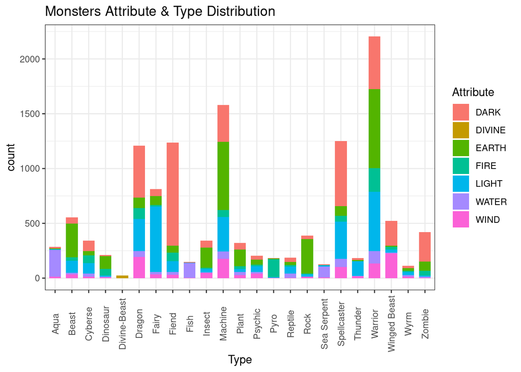

```r
theme_set(theme_bw())

ggplot(df_final) +
  labs(title="Monsters Attribute & Type Distribution") +
  geom_bar(aes(Type, fill=Attribute), width=0.7) +
  theme(axis.text.x = element_text(angle=90, vjust=0.5))
```

Quite a lot we can gain here. Firstly, surprise! Dragon-type is not the winner. I see that KONAMI actually prefers Warrior-Type a lot, with it’s notable Attributes: DARK, LIGHT, and EARTH. Some of you may already know what’s the biggest, best, the most famous warrior Archetype. Yes, the “HERO” Archetype.

Some of the “HERO” sub-archetype that I can think of are:

- **Elemental HERO** (Warrior-type monsters with various Attributes)
- **Destiny HERO** (Warrior-type monsters with all their member being DARK Attributes)
- **Masked HERO** (Fusion Warrior-type monsters with a single monster material)
- **Neos** (Fusion Warrior-type monsters that relies on “Elemental HERO - Neos”, various Attributes)

And here’s some more notable mentions that are considered META on their prime era:

- Utopia (LIGHT, Xyz oriented)
- Phantom Knight (DARK)
- Noble Knight (LIGHT & DARK)
- Tellarknight (LIGHT)
- Ignknight (not common, but I think it’s the most famous FIRE-Warrior archetype)
- Six Samurai (various)

And then the second highest is Machine-type. I think I can already infer that the reason behind this high number of Machine & Warrior-type monsters. Possibly it’s because:

- **GX series** : The main character, Jaden Yuki, uses Elemental HERO as it’s main deck.
- **5D’s series** : in 5D’s series, the main character, Yusei Fudo, uses an Archetype called “Synchron”. And these are mainly Machines & Warrior type monsters that are geared towards fast Synchro Monsters summoning.
- **ZeXal** : in this series, the main character, Yuma Tsukumo, uses a deck which consists mainly of Warrior-type, monsters.

Often, demands for supporting cards for Archetypes used by main characters are high. No wonder KONAMI still releases overly abundant Warrior & Machine type monsters up to this day.

### 4.1.2 Monster Card Type

Let’s take a look, which are more favourable, is it still Xyz monsters? I will filter out the ordinary Effect monsters, since they are always present in every deck.

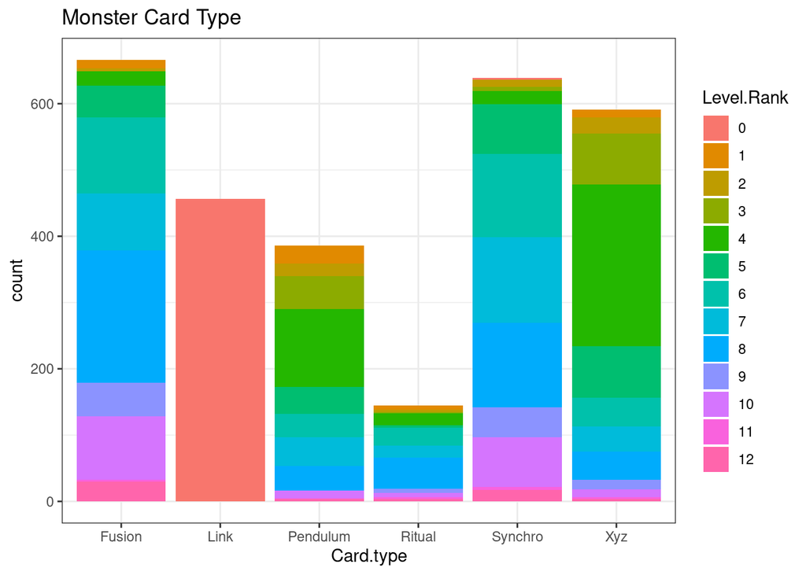

```r
card_selection <- dplyr::filter(df_final, Card.type != "Effect")
card_selection$Level.Rank <- factor(card_selection$Level.Rank)

ggplot(card_selection) +
  labs(title="Monster Card Type") +
  geom_bar(aes(Card.type, fill=Level.Rank))
```

**NOTE**: I can’t do much about the Link monsters being level 0, the dataset does not provide their Link rating.

Now we see that the Xyz rank 4 is still favorable as always. I remembered the reason was because Rank-4 Xyz has really generic material, and many decks that run Level-4 Monsters can easily utilize them.

To my surprise, fusion monsters are still high. Possibly this is also the side-effects of HERO monsters. Remember, HERO Archetype are fusion-oriented.

The Synchro monsters are still high probably because Synchro based archetype are also very common. During the 5D’s era, KONAMI drops a bombardment of new Archetypes that are synchro related. And recently, I heard recently KONAMI drops another support for Stardust Dragon (Yusei Fudo’s main monster), which means that Synchro oriented decks aren’t going down soon.

And finally, Link vs Pendulum, I see that people actually prefers Link monsters! Glad to hear that, I always find the ruling of Pendulum monsters quite confusing. But there’s also this second reason…

Link monsters are a MUST if your deck relies on Extra Decks (either Xyz, Synchro, and Fusion monsters). This is because if you don’t use Link monsters as per the latest **Master Rule**, you can only have 1 monster that are summoned from Extra Deck. [Read more about this rule](https://yugioh.fandom.com/wiki/Link_Arrow)

This is probably why KONAMI decides to drop a bombardment of Link monsters, despite Pendulum monsters came first.

### 4.1.3 Monster Attribute

Now, let’s take a look at the distribution of the Attributes itself.

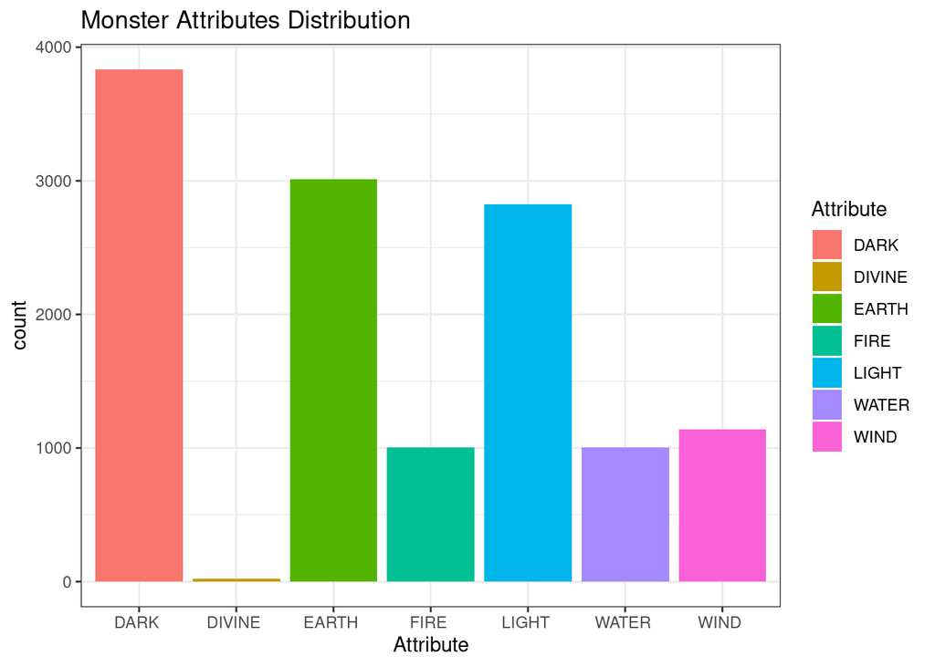

```r
ggplot(df_final) +
  labs(title="Monster Attributes Distribution") +
  geom_bar(aes(Attribute, fill=Attribute))
```

As we can see, the number of the Effect monsters are ranked as follows:

1. DARK
2. EARTH
3. LIGHT

There’s only 1 possibility why DARK & LIGHT are at the top 3. It’s because “Chaos” deck playstyle exist. This so-called “Chaos” deck are decks that relies on various DARK & LIGHT monsters, often coming from different Archetype / Type! And what’s more amazing are, the “Chaos” deck is considered to be very versatile, any player with decks that can utilize DARK & LIGHT Monsters, have “Chaos” playstyle as one of their options!

This is why KONAMI did not stop creating supports for DARK & LIGHT monsters.

### 4.1.4 Monsters Level vs Banlist Relation

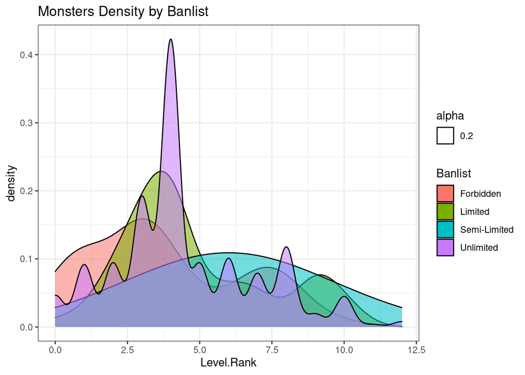

```r
theme_set(theme_bw())

level_banlist_density <- ggplot(df_final) +
  geom_density(aes(Level.Rank, fill=Banlist, alpha=0.2)) +
  labs(title="Monsters Density by Banlist")

level_banlist_density
```

The reason why I visualize the **Level / Rank** and **Banlist** together is, because this particular rule: “Monsters of level 5 or higher requires tributing (sacrificing) a monster”.

Think of it, monsters are mostly banned because their effects can easily change the tide of the duel. How scary it is to summon those monsters without tribute?

Look at the density of monsters ranging from Level 2-4. Monsters labeled as **Forbidden** & **Limited** are obviously gathering there. This means that the most “favourable” monsters (favourable in YGO can be translated as = soon to be banned LMAO), are those that **Can be summoned easily** and because they are in the banlist, this means **they also have good effects**.

Here are some notable monsters on the banlist:

- **Yata-Garasu** - L1 (famous for deadlock during the first era of YGO 2004)
- **Dandelion** - L3 (easy token abuse)
- **Glow-up Bulb** - L1 (this 1 monster can create a deadly combo of 5 high level monsters in 1 turn)